# IODS course project

Julia Hellstrand

# About the project

*I have a very tight schedule at the moment, and I am not sure whether I will have time to complete the exercises on time. I will try my best, though.*

*Link: https://github.com/JuliaH1994/IODS-project*

# Chapter 2: Regression and model validation

## Exercises about regression and model validation

**1**

```r
data <- read.csv("Z:\\IODS\\IODS\\data\\learning2014.csv")
data <- data[,2:8]
head(data)
```

```
##   gender Age Attitude     deep  stra     surf Points
## 1      F  53       37 3.583333 3.375 2.583333     25
## 2      M  55       31 2.916667 2.750 3.166667     12
## 3      F  49       25 3.500000 3.625 2.250000     24
## 4      M  53       35 3.500000 3.125 2.250000     10
## 5      M  49       37 3.666667 3.625 2.833333     22
## 6      F  38       38 4.750000 3.625 2.416667     21
```

```r
dim(data)
```

```
## [1] 166   7
```

```r
str(data)
```

```
## 'data.frame':    166 obs. of  7 variables:
##  $ gender  : Factor w/ 2 levels "F","M": 1 2 1 2 2 1 2 1 2 1 ...
##  $ Age     : int  53 55 49 53 49 38 50 37 37 42 ...
##  $ Attitude: int  37 31 25 35 37 38 35 29 38 21 ...
##  $ deep    : num  3.58 2.92 3.5 3.5 3.67 ...
##  $ stra    : num  3.38 2.75 3.62 3.12 3.62 ...
##  $ surf    : num  2.58 3.17 2.25 2.25 2.83 ...
##  $ Points  : int  25 12 24 10 22 21 21 31 24 26 ...
```

The data contains 7 variables and 166 observations. The variables are gender, age, attitude, deep, stra, surf and points. Deep, stra and surf are combinations of several variables related to deep, surface and strategic learning.

**2**

```r
summary(data)
```

```
##  gender       Age           Attitude          deep            stra
##  F:110   Min.   :17.00   Min.   :14.00   Min.   :1.583   Min.   :1.250
##  M: 56   1st Qu.:21.00   1st Qu.:26.00   1st Qu.:3.333   1st Qu.:2.625
##          Median :22.00   Median :32.00   Median :3.667   Median :3.188
##          Mean   :25.51   Mean   :31.43   Mean   :3.680   Mean   :3.121
##          3rd Qu.:27.00   3rd Qu.:37.00   3rd Qu.:4.083   3rd Qu.:3.625
##          Max.   :55.00   Max.   :50.00   Max.   :4.917   Max.   :5.000
##       surf           Points
##  Min.   :1.583   Min.   : 7.00
##  1st Qu.:2.417   1st Qu.:19.00
##  Median :2.833   Median :23.00
##  Mean   :2.787   Mean   :22.72
##  3rd Qu.:3.167   3rd Qu.:27.75
##  Max.   :4.333   Max.   :33.00
```

```r
library(GGally)
```

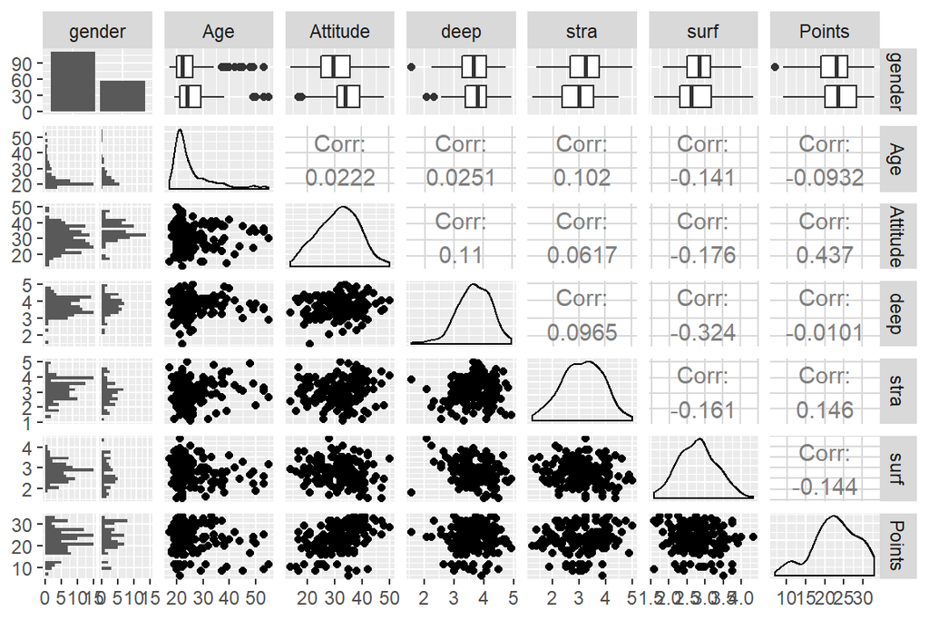

```r
library(ggplot2)
p <- ggpairs(data, mapping = aes(), lower = list(combo = wrap("facethist", bins = 20)))
p
```

There are 110 females and 56 males in the data set. Age ranges from 17 to 55 with the mean age at 25.51. Attitude varies from 14 to 50, deep, stra, and surf vary from approx. 1 to 5, and points varies from 7 to 33. The strongest correlation is found between points and attutude.

**3**

```r
lm1 <- lm(Points ~ Attitude + stra + surf, data=data)
summary(lm1)
```

```
##
## Call:
## lm(formula = Points ~ Attitude + stra + surf, data = data)
##
## Residuals:
##      Min       1Q   Median       3Q      Max
## -17.1550  -3.4346   0.5156   3.6401  10.8952
##
## Coefficients:
##             Estimate Std. Error t value Pr(>|t|)
## (Intercept) 11.01711    3.68375   2.991  0.00322 **
## Attitude     0.33952    0.05741   5.913 1.93e-08 ***
## stra         0.85313    0.54159   1.575  0.11716
## surf        -0.58607    0.80138  -0.731  0.46563
## ---
## Signif. codes:  0 '***' 0.001 '**' 0.01 '*' 0.05 '.' 0.1 ' ' 1
##
## Residual standard error: 5.296 on 162 degrees of freedom
## Multiple R-squared:  0.2074, Adjusted R-squared:  0.1927
## F-statistic: 14.13 on 3 and 162 DF,  p-value: 3.156e-08
```

Attitude is the only significant variable.

```r
lm2 <- lm(Points ~ Attitude, data=data)
summary(lm2)
```

```
##
## Call:
## lm(formula = Points ~ Attitude, data = data)
##
## Residuals:
##      Min       1Q   Median       3Q      Max
## -16.9763  -3.2119   0.4339   4.1534  10.6645
##
## Coefficients:
##             Estimate Std. Error t value Pr(>|t|)
## (Intercept) 11.63715    1.83035   6.358 1.95e-09 ***
## Attitude     0.35255    0.05674   6.214 4.12e-09 ***
## ---
## Signif. codes:  0 '***' 0.001 '**' 0.01 '*' 0.05 '.' 0.1 ' ' 1
##
## Residual standard error: 5.32 on 164 degrees of freedom
## Multiple R-squared:  0.1906, Adjusted R-squared:  0.1856
## F-statistic: 38.61 on 1 and 164 DF,  p-value: 4.119e-09
```

**4** When attitude increases with one unit, points increases with 0.35. The model explains 19% of the variation.

**5**

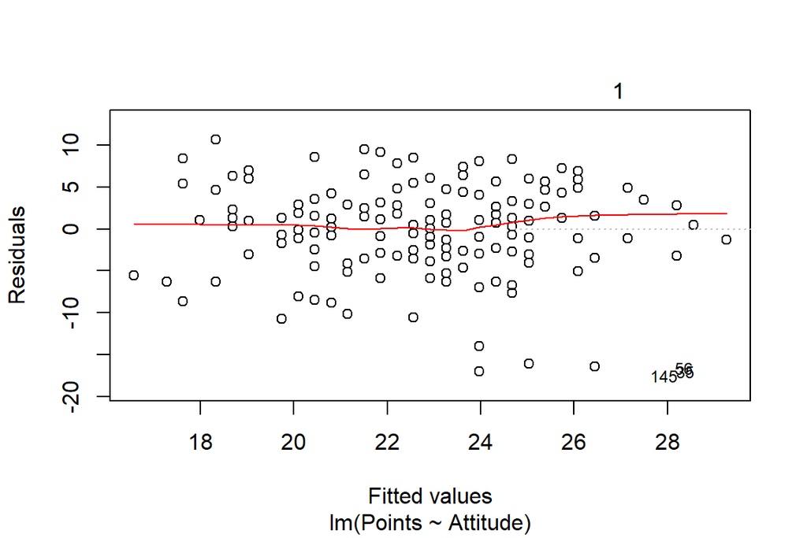

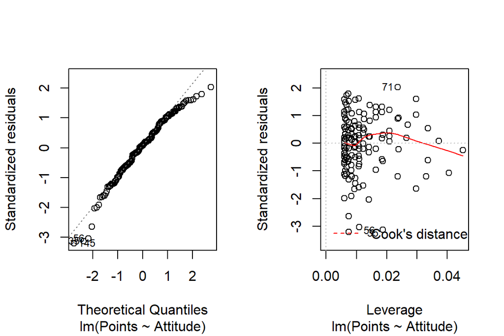

```r
plot(lm2, which = c(1, 2, 5), par(mfrow = c(1,2)))
```

Residuals should be normally distrbuted with constant variance.

Residuals vs. Fitted values: Close to constant variation of residual errors. (No pattern should be observed) QQ-plot: Normality assumption of errors is ok! (Should fit the line) Leverage: OK! (a measure of how far an observation on the predictor variable from the mean of the predictor variable)

# Chapter 3: Logistic regression

## Exercises about logistic regression

**1-2 Create a new R Markdown file and Read the joined student alcohol consumption data**

```r
setwd("Z:\\IODS\\IODS\\data")
data <- read.csv("alc.csv",sep=",")
str(data)
```

```
## 'data.frame':    382 obs. of  35 variables:
##  $ school    : Factor w/ 2 levels "GP","MS": 1 1 1 1 1 1 1 1 1 1 ...
##  $ sex       : Factor w/ 2 levels "F","M": 1 1 1 1 1 2 2 1 2 2 ...
##  $ age       : int  18 17 15 15 16 16 16 17 15 15 ...
##  $ address   : Factor w/ 2 levels "R","U": 2 2 2 2 2 2 2 2 2 2 ...
##  $ famsize   : Factor w/ 2 levels "GT3","LE3": 1 1 2 1 1 2 2 1 2 1 ...
##  $ Pstatus   : Factor w/ 2 levels "A","T": 1 2 2 2 2 2 2 1 1 2 ...
##  $ Medu      : int  4 1 1 4 3 4 2 4 3 3 ...
##  $ Fedu      : int  4 1 1 2 3 3 2 4 2 4 ...
##  $ Mjob      : Factor w/ 5 levels "at_home","health",..: 1 1 1 2 3 4 3 3 4 3 ...
##  $ Fjob      : Factor w/ 5 levels "at_home","health",..: 5 3 3 4 3 3 3 5 3 3 ...
##  $ reason    : Factor w/ 4 levels "course","home",..: 1 1 3 2 2 4 2 2 2 2 ...
##  $ nursery   : Factor w/ 2 levels "no","yes": 2 1 2 2 2 2 2 2 2 2 ...
##  $ internet  : Factor w/ 2 levels "no","yes": 1 2 2 2 1 2 2 1 2 2 ...
##  $ guardian  : Factor w/ 3 levels "father","mother",..: 2 1 2 2 1 2 2 2 2 2 ...
```

[output cut: 21 more lines]

The dataset includes information about student achievement in secondary education of two Potugese schools. It has 382 observations and 35 variables. The variables are student grades, and demographic, social and school related features.

The dataset is a combination of two datasets: Mathematics (mat) and Portugese language (por).

**3 Personal hypothesis**

I chose the following four variables to study their relationships with high/low alcohol consumption:

sex - student’s sex (binary: ‘F’ - female or ‘M’ - male) Males are more likely to have high alcohol consumption.

Pstatus - parent’s cohabitation status (binary: ‘T’ - living together or ‘A’ - apart) Students with parent’s living apart are more likely to have high alcohol consumption.

studytime - weekly study time (numeric: 1 - <2 hours, 2 - 2 to 5 hours, 3 - 5 to 10 hours, or 4 - >10 hours) Students with less study time are more likely to have high alcohol consumption.

absences - number of school absences (numeric: from 0 to 93) Students with high number of school absences are more likely to have high alcohol consumption.

**4 The distributions of the chosen variables**

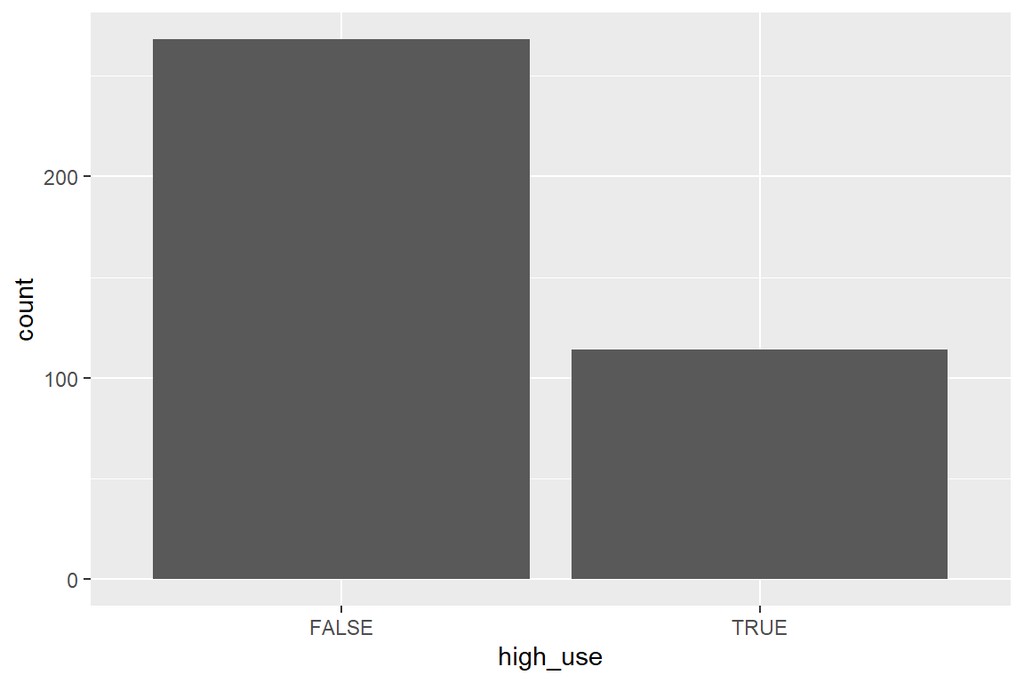

```r
library(ggplot2)
g1 <- ggplot(data, aes(x = high_use))
g1 + geom_bar()
```

Less then one out of three students have high alcohol consumption.

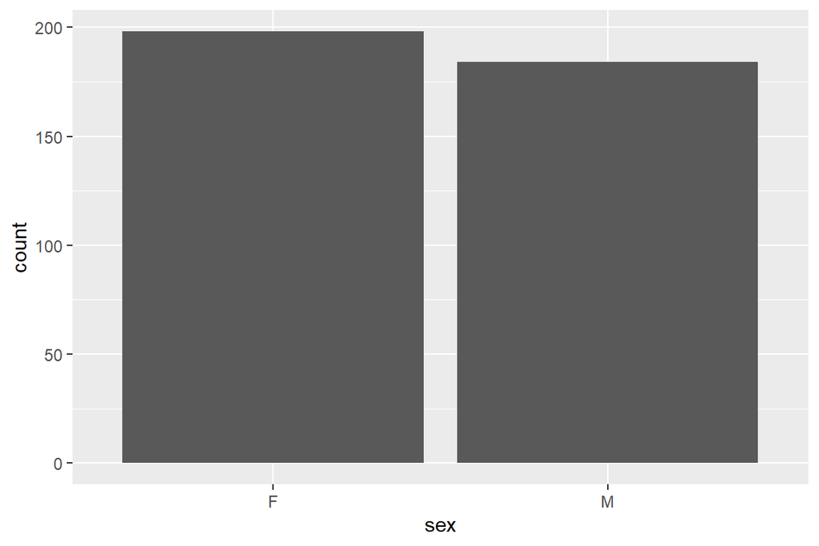

```r
g2 <- ggplot(data, aes(x = sex))
g2 + geom_bar()
```

There are rougly the same numeber of boys and girls, only slihgly more girls.

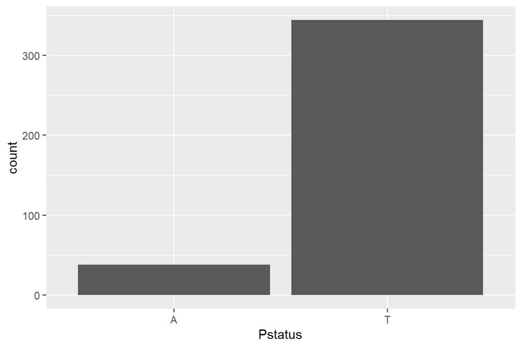

```r
g3 <- ggplot(data, aes(x = Pstatus))
g3 + geom_bar()
```

Most students have parents living together.

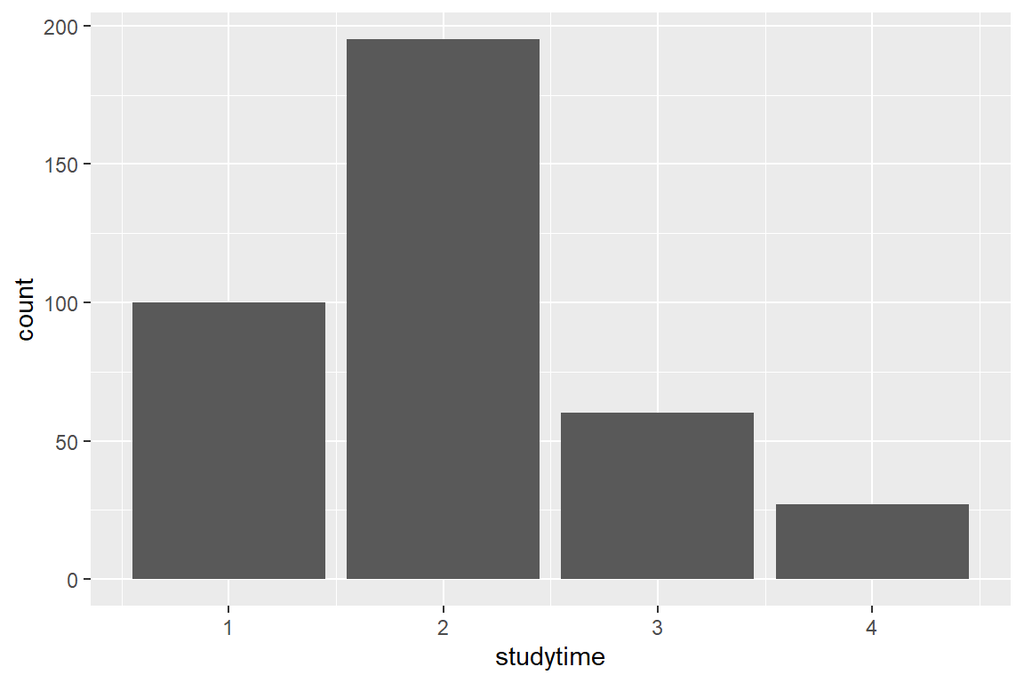

```r
g4 <- ggplot(data, aes(x = studytime))
g4 + geom_bar()
```

Most students use 2 to 5 hours per week to study (2). Only a small number studies more than 10 hours (4)

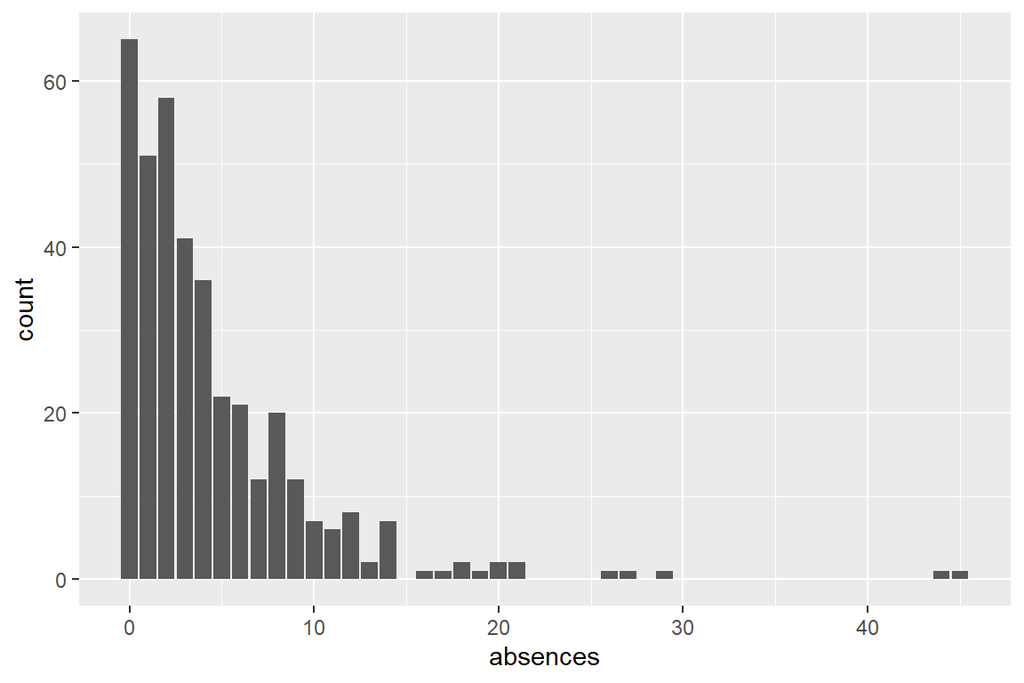

```r
g5 <- ggplot(data, aes(x = absences))
g5 + geom_bar()
```

It is quite common to have 0-4 school absences, but only a few has more than 10 absences.

```r
prop.table(table(data$sex,data$high_use),1)
```

```
##
##         FALSE      TRUE
##   F 0.7878788 0.2121212
##   M 0.6086957 0.3913043
```

39 percent of boys have a high alcohol consumption compared to 21 percent of girls.

```r
prop.table(table(data$Pstatus,data$high_use),1)
```

```
##
##         FALSE      TRUE
##   A 0.6842105 0.3157895
##   T 0.7034884 0.2965116
```

Slightly more (32 percent) students with parents living apart have high alcohol consumption compared to students with parents living together (30 percent).

```r
prop.table(table(data$studytime,data$high_use),1)
```

```
##
##         FALSE      TRUE
##   1 0.5800000 0.4200000
##   2 0.6923077 0.3076923
##   3 0.8666667 0.1333333
##   4 0.8518519 0.1481481
```

The group with the shortest study time has the highest proportion (42 percent) of high alcohol consumption, and the proportion decreases with study time (below 15 percent in group 3 and 4).

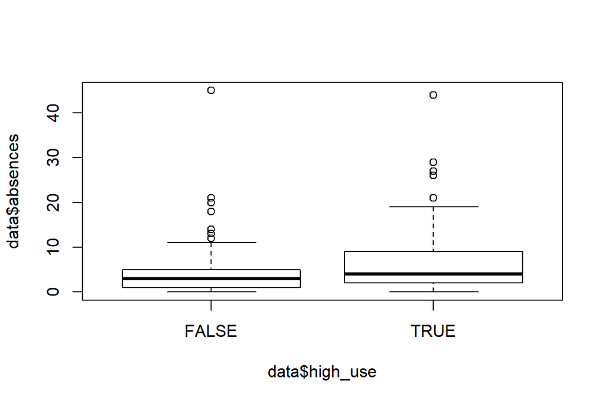

```r
boxplot(data$absences ~ data$high_use)
```

Those with high alcohol consumption seem to have more absences.

My hyphothesis were 1) Males are more likely to have high alcohol consumption. 2) Students with parent’s living apart are more likely to have high alcohol consumption. 3) Students with less study time are more likely to have high alcohol consumption. 4) Students with high number of school absences are more likely to have high alcohol consumption.

There seems to be evidence for 1), 3) and 4), but not for 2).

**5 Logistic regression**

```r
library(dplyr)
m <- glm(high_use ~ sex + Pstatus + studytime + absences, data, family = "binomial")

summary(m)
```

```
##
## Call:
## glm(formula = high_use ~ sex + Pstatus + studytime + absences,
##     family = "binomial", data = data)
##
## Deviance Residuals:
##     Min       1Q   Median       3Q      Max
## -2.1471  -0.8513  -0.5998   1.0938   2.1119
##
## Coefficients:
##             Estimate Std. Error z value Pr(>|z|)
## (Intercept) -1.01671    0.55552  -1.830 0.067222 .
## sexM         0.79596    0.25085   3.173 0.001508 **
## PstatusT     0.10805    0.40260   0.268 0.788405
## studytime   -0.40252    0.15929  -2.527 0.011502 *
## absences     0.08937    0.02316   3.858 0.000114 ***
## ---
## Signif. codes:  0 '***' 0.001 '**' 0.01 '*' 0.05 '.' 0.1 ' ' 1
##
## (Dispersion parameter for binomial family taken to be 1)
##
##     Null deviance: 465.68  on 381  degrees of freedom
## Residual deviance: 423.20  on 377  degrees of freedom
## AIC: 433.2
##
## Number of Fisher Scoring iterations: 4
```

All variables but Pstatus are statistically signigicant. We find support of sex, studytime, and absences being related to high alcohol consumption.

```r
OR <- coef(m) %>% exp
CI <- confint(m) %>% exp
cbind(OR,CI)
```

```
##                    OR     2.5 %    97.5 %
## (Intercept) 0.3617838 0.1183205 1.0550291
## sexM        2.2165712 1.3610279 3.6461108
## PstatusT    1.1141046 0.5186440 2.5463294
## studytime   0.6686307 0.4847655 0.9067313
## absences    1.0934841 1.0471362 1.1468441
```

Boys are 2.2 times as likely (CI 1.4;3.6) as girls to have high alcohol consumption, (holding the other variables constant).

Study time and high alcohol comsumption are negatively related: the more study time, the less likely of high alcohol consumption. When study time increases with one unit, having high alcohol consumption becomes 33 percent (1-0.67) less likely, (holding the other variables constant).

Absences and high alcohol comsumption are positively related: the more absencses, the more likely of high alcohol consumption. When absences increases with one unit, the odds of having high alcohol consumption increases with 9 percent (CI 5%;15%), (holding the other variables constant).

Once again, the findings support hypothesis 1), 3) and 4), but not 2).

**6 Explore the predictive power of the model**

Fit the same model, but drop the non significant variable Pstatus.

```r
m <- glm(high_use ~ sex + studytime + absences, data, family = "binomial")

probabilities <- predict(m, type = "response")

data <- mutate(data, probability = probabilities)
data <- mutate(data, prediction = probability > 0.5)

table(high_use = data$high_use, prediction = data$prediction)
```

```
##         prediction
## high_use FALSE TRUE
##    FALSE   258   10
##    TRUE     88   26
```

The model correcly predicted 258 to be FALSE when they actually were FALSE, and 26 to be TRUE when they actually were TRUE. The model incorrectly predicted 10 to be TRUE when they actually were FALSE, and 88 to be FALSE when they actually were TRUE.

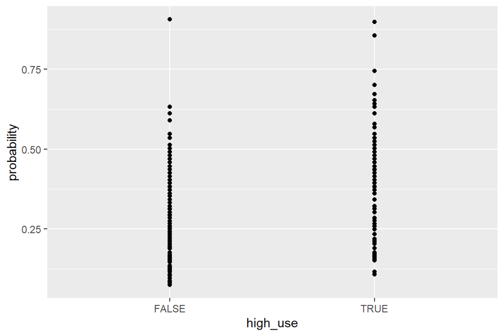

```r
g <- ggplot(data, aes(x = high_use, y = probability))
g+geom_point()
```

The model predicts most of the FALSE values correctly, but fails to predict a large proportion of the TRUE values.

```r
loss_func <- function(class, prob) {
  n_wrong <- abs(class - prob) > 0.5
  mean(n_wrong)
}

loss_func(class = data$high_use, prob = data$probability)
```

```
## [1] 0.2565445
```

26 percent were predicted incorrectly. This could also be read from the previous table (88+10)/(258+10+88+26).

```r
loss_func(class = data$high_use, prob = 0)
```

```
## [1] 0.2984293
```

Define the probability of high_use as zero for each individual. 30 percent were predicted incorrectly. The model preforms better (but not much better!) than simply giving all probability 0.

**7**

```r
library(boot)
cv <- cv.glm(data, cost = loss_func, glmfit = m, K = 10)
cv$delta[1]
```

```
## [1] 0.2643979
```

No.